# SIR and SIRS Models

The SIR model was first used by Kermack and McKendrick in 1927 and has subsequently been applied to a variety of diseases, especially airborne childhood diseases with lifelong immunity upon recovery, such as measles, mumps, rubella, and pertussis. S, I and R represent the number of susceptible, infected, and recovered individuals, and N = S + I + R is the total population.

This topic describes the differential equations that govern the classic deterministic SIR and SIRS compartmental models. In SIR models, individuals in the recovered state gain total immunity to the pathogen; in SIRS models, that immunity wanes over time and individuals can become reinfected.

The SIR/SIRS diagram below shows how individuals move through each compartment in the model. The dashed line shows how the SIR model becomes an SIRS (Susceptible - Infectious - Recovered - Susceptible) model, where recovery does not confer lifelong immunity, and individuals may become susceptible again.

[figure not shown]

## SIR Model

If the course of the infection is short (emergent outbreak) compared with the lifetime of an individual and the disease is non-fatal, vital dynamics (birth and death) can be ignored. In the deterministic form, the SIR model can be written as the following ordinary differential equation (ODE):

[figure not shown]

where *N = S + I + R* is the total population.

Model parameters are provided below.

The modelling time is 60 days with a step of 0.5 days. Infection lasts for 5 days and waning time is 10 days. The transmission factor is 5e-9. The population number is 100,000,000 people. Including 100,000 infectious people and 1,000,000 recovered people. The model simulation is coded next.

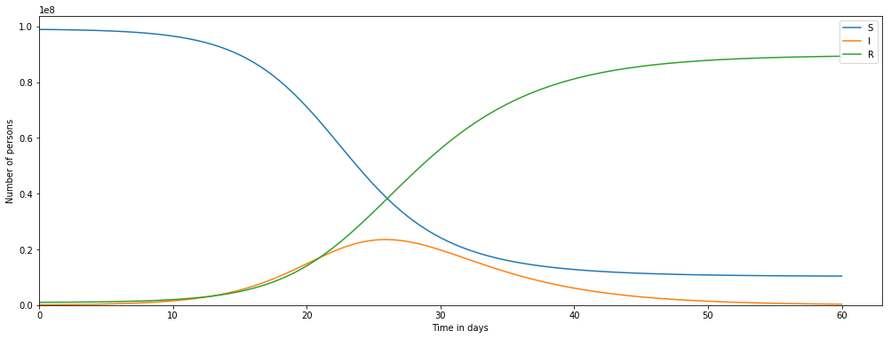

```python
import numpy
import matplotlib.pyplot as plt

h = 0.5 # days
end_time = 60. # days
num_steps = int(end_time / h)
times = h * numpy.array(range(num_steps + 1))

def waning():
    transmission_coeff = 5e-9 # 1 / (day * person)
    infectious_time = 5. # days

    waning_time = 10. # days

    s = numpy.zeros(num_steps + 1)
    i = numpy.zeros(num_steps + 1)
    r = numpy.zeros(num_steps + 1)

    s[0] = 1e8 - 1e6 - 1e5
    i[0] = 1e5
    r[0] = 1e6

    s2i_values = []
    i2r_values = []
    r2s_values = []

    for step in range(num_steps):
        s2i = h * transmission_coeff * s[step] * i[step]
        i2r = h / infectious_time * i[step]
        r2s = 0

        s[step + 1] = s[step] - s2i
        i[step + 1] = i[step] + s2i - i2r
        r[step + 1] = r[step] + i2r

        s2i_values.append(s2i)
        i2r_values.append(i2r)
        r2s_values.append(r2s)

    return s, i, r, s2i_values, i2r_values, r2s_values

s, i, r, s2i_values, i2r_values, r2s_values = waning()

def SIRplot():
    plt.figure(figsize=(17, 6))
    s_plot = plt.plot(times, s, label = 'S')
    i_plot = plt.plot(times, i, label = 'I')
    r_plot = plt.plot(times, r, label = 'R')
    plt.legend(('S', 'I', 'R'), loc = 'upper right')

    axes = plt.gca()
    axes.set_xlabel('Time in days')
    axes.set_ylabel('Number of persons')
    plt.xlim(xmin = 0.)
    plt.ylim(ymin = 0.)

SIRplot()

def diffSIRplot():
    plt.figure(figsize=(17, 6))
    s_plot = plt.plot(times[1:], s2i_values, label = 's2i')
    i_plot = plt.plot(times[1:], i2r_values, label = 'i2r')
    r_plot = plt.plot(times[1:], r2s_values, label = 'r2s')
    plt.legend(('s2i', 'i2r', 'r2s'), loc = 'upper right')

    axes = plt.gca()
    axes.set_xlabel('Time in days')
    axes.set_ylabel('Number of persons per day')
    plt.xlim(xmin = 0.)
    plt.ylim(ymin = 0.)
```

As can be seen from the above figure the disease starts to slow down after 26 days and number of infectious people deceases gradually towards zero. This due to the fact that after getting the disease the recovered people are immune to it. So after some time there are no longer many people who can get the disease.

Next we can plot rate of change of people from susceptible to infections (s2i) and infectious to recovered (i2r). The rate of change of recovered to susceptible (r2s) is zero in the case of SIR model.

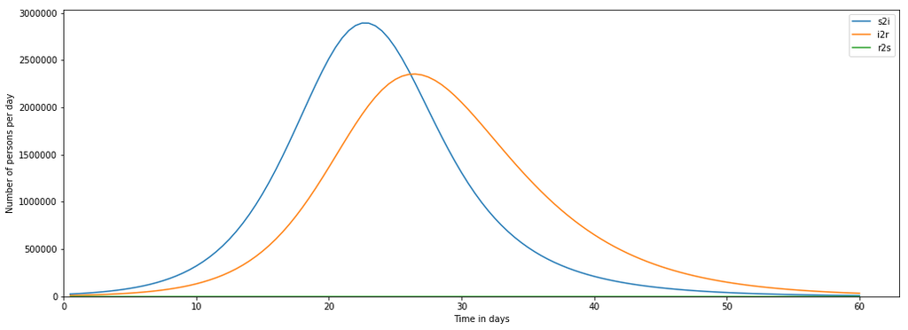

```python
diffSIRplot()
```

The SIR model assumes people carry lifelong immunity to a disease upon recovery; this is the case for a variety of diseases. For another class of airborne diseases, for example seasonal influenza, an individual’s immunity may wane over time. In this case, the SIRS model is used allow recovered individuals return to a susceptible state.

Next we will consider a case of SIRS model were a proportion of recovered people turn susceptible once again after some time.

If there is sufficient influx to the susceptible population, at equilibrium the dynamics will be in an endemic state with damped oscillation. THe ODE then becomes:

[figure not shown]

where *N = S + I + R* is the total population.

## SIRS Model

Waning immunity in SIRS model means that people can eventually become susceptible again. The time constant waning time is set so that there are twice as many recovered people as there are infected people.

The modelling time is 60 days with a step of 0.5 days. Infection lasts for 5 days and waning time is 10 days. The transmission factor is 5e-9. The population number is 100,000,000 people. Including 100,000 infectious people and 1,000,000 recovered people.

The model simulation is visualised below.

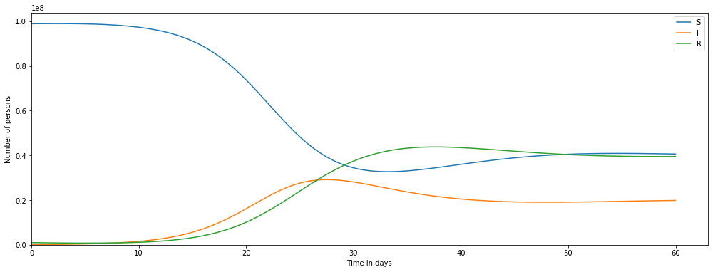

```python
import numpy
import matplotlib.pyplot as plt

h = 0.5 # days
end_time = 60. # days
num_steps = int(end_time / h)
times = h * numpy.array(range(num_steps + 1))

def waning():
    transmission_coeff = 5e-9 # 1 / (day * person)
    infectious_time = 5. # days

    waning_time = 10. # days

    s = numpy.zeros(num_steps + 1)
    i = numpy.zeros(num_steps + 1)
    r = numpy.zeros(num_steps + 1)

    s[0] = 1e8 - 1e6 - 1e5
    i[0] = 1e5
    r[0] = 1e6

    s2i_values = []
    i2r_values = []
    r2s_values = []

    for step in range(num_steps):
        s2i = h * transmission_coeff * s[step] * i[step]
        i2r = h / infectious_time * i[step]
        r2s = h / waning_time * r[step]

        s[step + 1] = s[step] - s2i + r2s
        i[step + 1] = i[step] + s2i - i2r
        r[step + 1] = r[step] + i2r - r2s

        s2i_values.append(s2i)
        i2r_values.append(i2r)
        r2s_values.append(r2s)

    return s, i, r, s2i_values, i2r_values, r2s_values

s, i, r, s2i_values, i2r_values, r2s_values = waning()

def SIRSplot():
    plt.figure(figsize=(17, 6))
    s_plot = plt.plot(times, s, label = 'S')
    i_plot = plt.plot(times, i, label = 'I')
    r_plot = plt.plot(times, r, label = 'R')
    plt.legend(('S', 'I', 'R'), loc = 'upper right')

    axes = plt.gca()
    axes.set_xlabel('Time in days')
    axes.set_ylabel('Number of persons')
    plt.xlim(xmin = 0.)
    plt.ylim(ymin = 0.)

SIRSplot()

def diffSIRSplot():
    plt.figure(figsize=(17, 6))
    s_plot = plt.plot(times[1:], s2i_values, label = 's2i')
    i_plot = plt.plot(times[1:], i2r_values, label = 'i2r')
    r_plot = plt.plot(times[1:], r2s_values, label = 'r2s')
    plt.legend(('s2i', 'i2r', 'r2s'), loc = 'upper right')

    axes = plt.gca()
    axes.set_xlabel('Time in days')
    axes.set_ylabel('Number of persons per day')
    plt.xlim(xmin = 0.)
    plt.ylim(ymin = 0.)
```

The figure shows that after about 60 days there is a equilibrium. The number of susceptible, infectious and recovered people does not change. It is important to notice that there are still about 20,000,000 infected people due to constant influx of new susceptible people from recovered group.

Finally we can plot the rate of change of people from susceptible to infections (s2i), infectious to recovered (i2r) and the recovered to susceptible (r2s). As expected the rates are almost at an equilibrium state by the end of the 60 days.

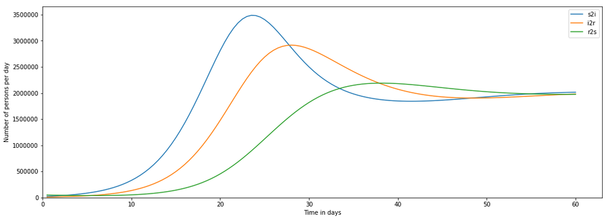

```python
diffSIRSplot()
```